# RWorksheet_Sumintao#4b

2023-11-08

#1.for() loop Using the for loop, create an R script that will display a 5x5 matrix as shown in Figure 1. It must contain vectorA = [1,2,3,4,5] and a 5 x 5 zero matrix.

```r
A <- c(1,2,3,4,5)
zero_matrix <- matrix(0, nrow = 5,ncol = 5)
matrix_result <- rbind(A, zero_matrix)
print(matrix_result)
```

```
##   [,1] [,2] [,3] [,4] [,5]
## A    1    2    3    4    5
##      0    0    0    0    0
##      0    0    0    0    0
##      0    0    0    0    0
##      0    0    0    0    0
##      0    0    0    0    0
```

#2. Print the string “*” using for() function. The output should be the same as shown in Figure

```r
for (i in 1:5){
jls <- rep ("*",i)
print(jls)
}
```

```
## [1] "*"
## [1] "*" "*"
## [1] "*" "*" "*"
## [1] "*" "*" "*" "*"
## [1] "*" "*" "*" "*" "*"
```

#3. Get an input from the user to print the Fibonacci sequence starting from the 1st inputup to 500. Use repeat and break statements. Write the R Scripts and its output.

```r
userInput <- as.integer(readline("Enter starting number for Fibonnacci sequence:"))
```

```
## Enter starting number for Fibonnacci sequence:
```

```r
if(is.na(userInput || userInput < 0)){
} else {
  x <- userInput
  y <- 0

  cat("Fibonacci sequence starting from", userInput, ":\n")

  repeat{

    next_num <- x + y

    if (next_num > 500){
      break
    }
    cat(next_num," ")
    x <- y
    y <- next_num
  }
}
```

[output not shown]

```r
read.csv("Household.csv")
```

[output not shown]

```r
head(Household)
```

[output not shown]

#5.The monthly income of Dela Cruz family was spent on the following:

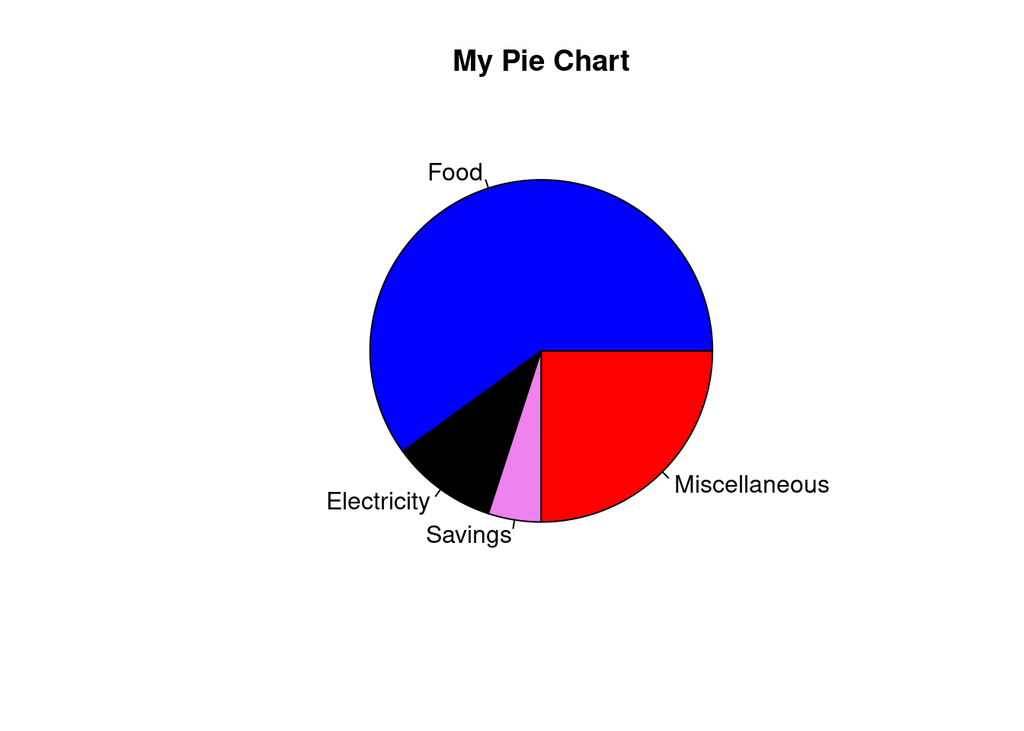

```r
data <- c(60, 10, 5, 25)
labels <- c("Food", "Electricity", "Savings", "Miscellaneous")
colors <- c("blue", "black", "violet", "red")
pie(data, labels = labels, col = colors, main = "My Pie Chart")
```

#6. Use the iris dataset.

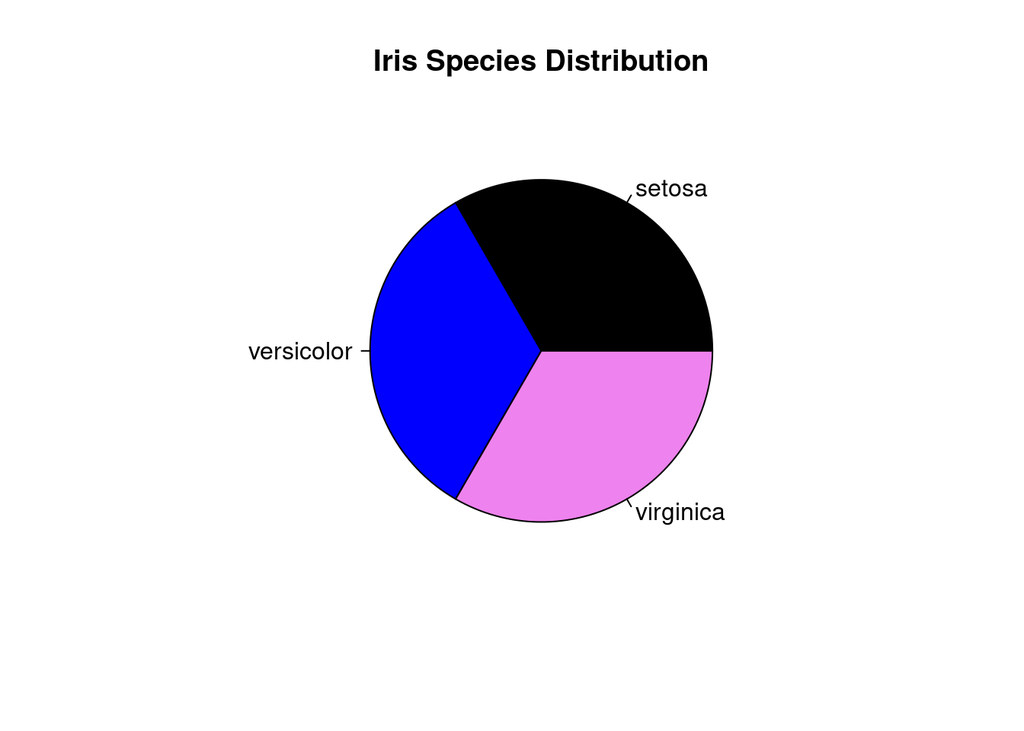

```r
data(iris)

species_count <- table(iris$Species)
colors <- c("black", "blue", "violet", "red")
pie(species_count, labels = levels(iris$Species), col = colors, main = "Iris Species Distribution")
```

#a. Check for the structure of the dataset using the str() function. Describe what you have seen in the output.

#b. Create an R object that will contain the mean of the sepal.length, sepal.width,petal.length,and petal.width. What is the R script and its result?

```r
means <- colMeans(iris[c("Sepal.Length", "Sepal.Width", "Petal.Length", "Petal.Width")])
means
```

```
## Sepal.Length  Sepal.Width Petal.Length  Petal.Width
##     5.843333     3.057333     3.758000     1.199333
```

#c. Create a pie chart for the Species distribution. Add title, legends, and colors. Write the R script and its result.

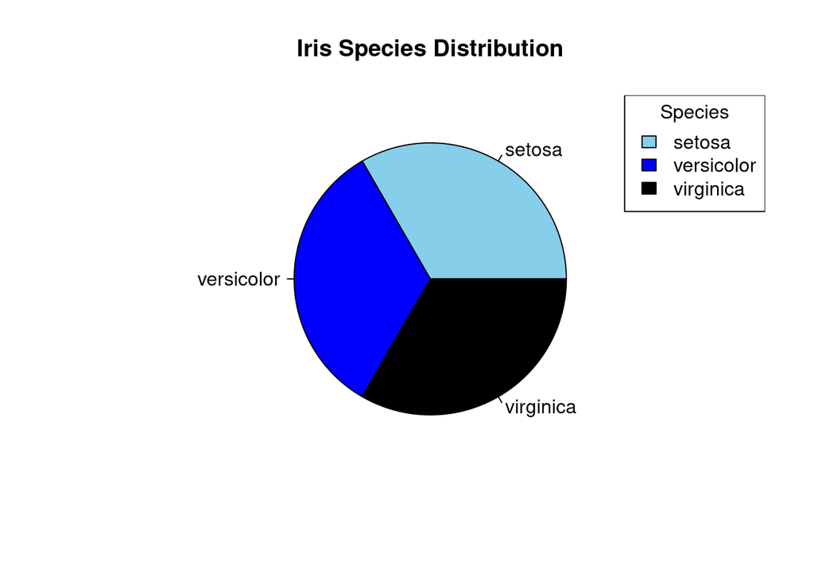

```r
data(iris)
species_count <- table(iris$Species)
colors <- c("skyblue", "blue", "black", "red")
pie(species_count, labels = levels(iris$Species), col = colors, main = "Iris Species Distribution")
legend("topright", legend = levels(iris$Species), fill =colors, title = "Species")
```

#d. Subset the species into setosa, versicolor, and virginica. Write the R scripts and show the last six (6) rows of each species.

```r
data(iris)
setosa_data <- subset(iris, Species == "setosa")
versicolor_data <- subset(iris, Species == "versicolor")
virginica_data <- subset(iris, Species == "virginica")

tail(setosa_data)
```

|  | Sepal.Length | Sepal.Width | Petal.Length | Petal.Width | Species |
| --- | --- | --- | --- | --- | --- |
| 45 | 5.1 | 3.8 | 1.9 | 0.4 | setosa |
| 46 | 4.8 | 3.0 | 1.4 | 0.3 | setosa |
| 47 | 5.1 | 3.8 | 1.6 | 0.2 | setosa |
| 48 | 4.6 | 3.2 | 1.4 | 0.2 | setosa |
| 49 | 5.3 | 3.7 | 1.5 | 0.2 | setosa |
| 50 | 5.0 | 3.3 | 1.4 | 0.2 | setosa |

```r
tail(versicolor_data)
```

|  | Sepal.Length | Sepal.Width | Petal.Length | Petal.Width | Species |
| --- | --- | --- | --- | --- | --- |
| 95 | 5.6 | 2.7 | 4.2 | 1.3 | versicolor |
| 96 | 5.7 | 3.0 | 4.2 | 1.2 | versicolor |
| 97 | 5.7 | 2.9 | 4.2 | 1.3 | versicolor |
| 98 | 6.2 | 2.9 | 4.3 | 1.3 | versicolor |
| 99 | 5.1 | 2.5 | 3.0 | 1.1 | versicolor |
| 100 | 5.7 | 2.8 | 4.1 | 1.3 | versicolor |

```r
tail(virginica_data)
```

|  | Sepal.Length | Sepal.Width | Petal.Length | Petal.Width | Species |
| --- | --- | --- | --- | --- | --- |
| 145 | 6.7 | 3.3 | 5.7 | 2.5 | virginica |
| 146 | 6.7 | 3.0 | 5.2 | 2.3 | virginica |
| 147 | 6.3 | 2.5 | 5.0 | 1.9 | virginica |
| 148 | 6.5 | 3.0 | 5.2 | 2.0 | virginica |
| 149 | 6.2 | 3.4 | 5.4 | 2.3 | virginica |
| 150 | 5.9 | 3.0 | 5.1 | 1.8 | virginica |

#e. Create a scatterplot of the sepal.length and sepal.width using the different species(setosa,versicolor,virginica). Add a title = “Iris Dataset”, subtitle = “Sepal width and length, labels for the x and y axis, the pch symbol and colors should be based on the species.

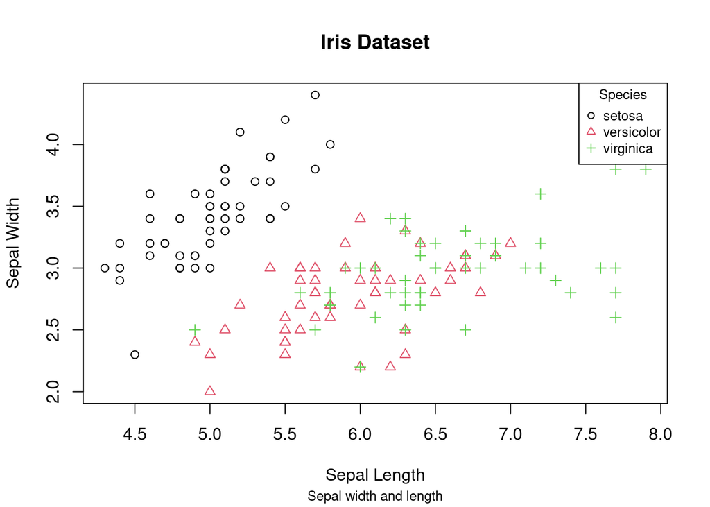

```r
data(iris)

plot(iris$Sepal.Length, iris$Sepal.Width,
     col = as.integer(iris$Species),
     pch = as.integer(iris$Species),
     xlab = "Sepal Length",
     ylab = "Sepal Width",
     main = "Iris Dataset",
     sub = "Sepal width and length",
     cex.main = 1.2,
     cex.sub = 0.8)

legend("topright", legend = levels(iris$Species),
       col = 1:length(levels(iris$Species)), pch = 1:length(levels(iris$Species)),
       title = "Species", cex = 0.8)
```

#Hint: Need to convert to factors the species to store categorical variables. #f. Interpret the result.

> To interpret the result of the scatterplot with categorical variables representing different species. Scatterplot Representation: –The scatterplot displays Sepal.Length on the x-axis and Sepal.Width on the y-axis. Each data point in the plot represents an iris flower. The colors and symbols differentiate between three species: setosa, versicolor, and virginica. One can analyze any patterns or clusters formed by these species concerning their sepal characteristics.

```r
install.packages("readxl")
library(readxl)
 file<-read_excel("alexa_file.xlsx")
```

[output not shown]

```r
alexa_file$variation <- gsub("Black  Dot", "BlackDot", alexa_file$variation)
```

[output not shown]

```r
alexa_file$variation <- gsub("Black  Plus", "BlackPlus", alexa_file$variation)
```

[output not shown]

```r
alexa_file$variation <- gsub("Black  Show", "BlackShow", alexa_file$variation)
```

[output not shown]

```r
alexa_file$variation <- gsub("Black  Spot", "BlackSpot", alexa_file$variation)
```

[output not shown]

```r
alexa_file$variation <- gsub("White  Dot", "WhiteDot", alexa_file$variation)
```

[output not shown]

```r
alexa_file$variation <- gsub("White  Plus", "WhitePlus", alexa_file$variation)
```

[output not shown]

```r
alexa_file$variation <- gsub("White  Show", "WhiteShow", alexa_file$variation)
```

[output not shown]

```r
alexa_file$variation <- gsub("White  Spot", "WhiteSpot", alexa_file$variation)
```

[output not shown]

```r
alexa_file
```

[output not shown]

```r
 barplot(table(variations_data),
 main = "Variations",
        xlab = "Variants",
        ylab = "Frequency",
        col = "blue",
        legend.text = TRUE)
```

[output not shown]

```r
text(x = 1:length(table(variations_data)),
     y = table(variations_data),
     label = as.character(table(variations_data)),
     pos = 3,
     cex = 0.8)
```

[output not shown]

```r
     legend("topright", legend = names(table(variations_data)),fill= "blue")
```

[output not shown]